# Homework Assignment 2

Murilo Pereira

2/7/2021

# 1 Fitting Gaussian and Student’s t ARMA(1,1) model

Simulating some data

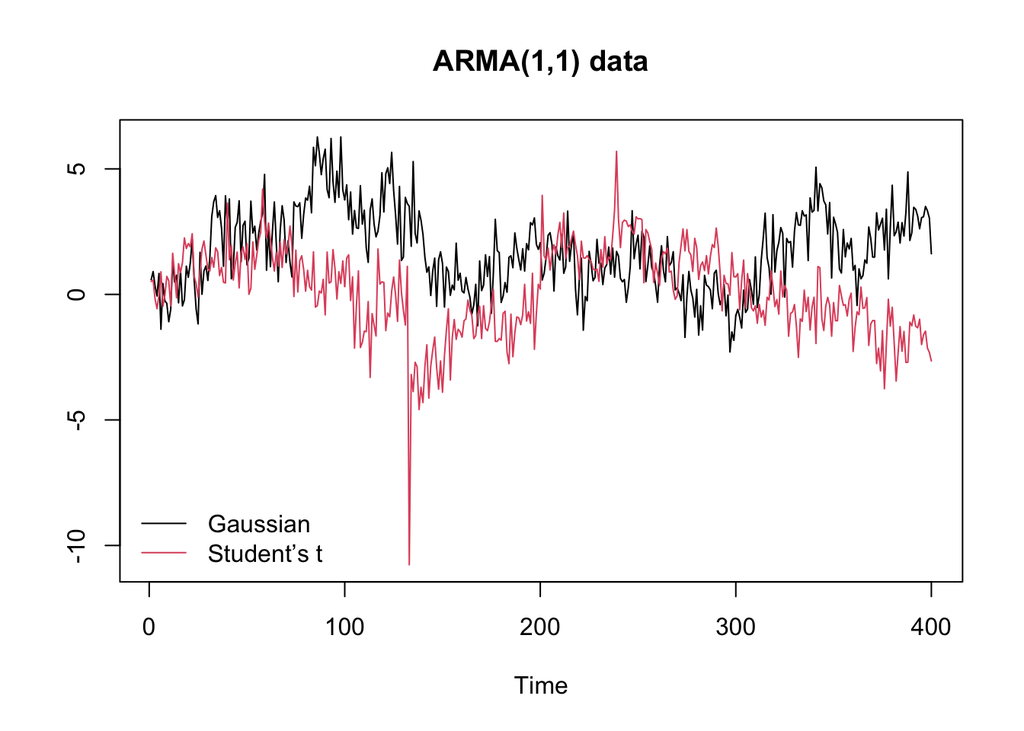

```r
set.seed(12345)
n =400
sig=1.0
nu=4
phi=0.98
theta=-0.64
tau = sqrt((nu-2)/nu)*sig
e.n = sig*rnorm(n)
e.t = tau*rt(n,df=nu)
y.n = rep(0,n)
y.t = rep(0,n)
y.n[1] = e.n[1]
y.t[1] = e.t[1]
for (t in 2:n){
y.n[t] = phi*y.n[t-1]+e.n[t]+theta*e.n[t-1]
y.t[t] = phi*y.t[t-1]+e.t[t]+theta*e.t[t-1]
}

## Plotting
par(mfrow=c(1,1))
ts.plot(cbind(y.n,y.t),col=1:2,main="ARMA(1,1) data")
legend("bottomleft",legend=c("Gaussian","Student’s t"),col=1:2,lty=1,bty="n")
```

# 2 Maximum likelihood inference.

Using R function “nlm” to minimize the negative of the likelihood functions for both models.

```r
## Preparing the data
y.n_1 <- rep(0,n)
y.n_1[2:400] <- y.n[1:399]
e.n_1 <- rep(0,n)
e.n_1[2:400] <- e.n[1:399]

y.t_1 <- rep(0,n)
y.t_1[2:400] <- y.t[1:399]
e.t_1 <- rep(0,n)
e.t_1[2:400] <- e.t[1:399]

## Negative of the loglikelihood functions
negllike.norm <-  function(thetas){-sum(dnorm((y.n-thetas[1]*y.n_1-thetas[2]*e.n_1)/sqrt(thetas[3]),log = TRUE)-log(sqrt(thetas[3])))}

logdt = function(m,s){dt((y.t-m)/sqrt(s),4,log=TRUE)-log(sqrt(s))}
negllike.t = function(thetas){-sum(logdt(thetas[1]*y.t_1+thetas[2]*e.t_1,thetas[3]))}

## nlm function
mle.norm <- nlm(negllike.norm,thetas <- c(0,0,1))
mle.t <- nlm(negllike.t,thetas <- c(0,0,1))
mle.norm
```

```
## $minimum
## [1] 574.1107
##
## $estimate
## [1]  1.0065313 -0.6874545  1.0332155
##
## $gradient
## [1] -4.116996e-04 -4.183676e-05 -4.456299e-05
##
## $code
## [1] 1
##
## $iterations
## [1] 16
```

```r
mle.t
```

```
## $minimum
## [1] 530.4749
##
## $estimate
## [1]  0.9535878 -0.6294269  0.5014020
##
## $gradient
## [1] -4.257572e-04 -7.605649e-05 -1.125500e-05
##
## $code
## [1] 1
##
## $iterations
## [1] 14
```

MLE estimates and ARIMA:

```r
## Estimates
norm.est <- c(phi.mle.norm <- mle.norm$estimate[1],
gamma.mle.norm <- mle.norm$estimate[2],
sig2.mle.norm <- mle.norm$estimate[3])

t.est <- c(phi.mle.t <- mle.t$estimate[1],
gamma.mle.t <- mle.t$estimate[2],
tau2.mle.t <- mle.t$estimate[3])

## ARIMA model
arima.norm <- arima(y.n, order=c(1,0,1))
arima.norm.est <- c(phi.arima.norm <- arima.norm$coef[1],
                    gamma.arima.norm <- arima.norm$coef[2],
                    sig2.arima.norm <- arima.norm$sigma2)

arima.t <- arima(y.t, order=c(1,0,1))
arima.t.est <- c(phi.arima.t <- arima.t$coef[1],
                    gamma.arima.t <- arima.t$coef[2],
                    sig2.arima.t <- arima.t$sigma2)
```

Comparison among estimates:

```r
table = round(rbind(norm.est,t.est,arima.norm.est,arima.t.est),9)
row.names(table) = c("Normal dist ","Studen's t dist","Normal ARIMA","Student's t ARIMA")
colnames(table)  =c("phi","gamma","sig2/tau2")
table
```

```
##                         phi      gamma sig2/tau2
## Normal dist       1.0065313 -0.6874545  1.033215
## Studen's t dist   0.9535878 -0.6294269  0.501402
## Normal ARIMA      0.9668333 -0.6558970  1.021405
## Student's t ARIMA 0.9750044 -0.6783247  1.108282
```

Just checking the results from a simple “lm” function

```r
fit.n <- lm(y.n~y.n_1+e.n_1)
fit.n
```

```
##
## Call:
## lm(formula = y.n ~ y.n_1 + e.n_1)
##
## Coefficients:
## (Intercept)        y.n_1        e.n_1
##      0.1919       0.9355      -0.6304
```

```r
fit.t <- lm(y.t~y.t_1+e.t_1)
fit.t
```

```
##
## Call:
## lm(formula = y.t ~ y.t_1 + e.t_1)
##
## Coefficients:
## (Intercept)        y.t_1        e.t_1
##   -0.003892     0.962133    -0.675138
```

# 3 Bayesian inference via Monte Carlo methods.

1. Now we will use sampling importance resampling (SIR) to sample from both posterior distributions of $\theta$
   $$\begin{array}{l}
   p\left(\theta \mid y^{n}, \mathcal{M}_{0}\right) \propto \mathcal{L}\left(\theta \mid y^{n}, \mathcal{M}_{0}\right) p(\theta) \\
   p\left(\theta \mid y^{n}, \mathcal{M}_{1}\right) \propto \mathcal{L}\left(\theta \mid y^{n}, \mathcal{M}_{1}\right) p(\theta)
   \end{array}$$
   First of all, I’ll define the likelihood, prior and proposal functions.

Notation: In the whole exercise we will be working with two models and two different DGPs. I’ll use “yt” and “yn” at the end of the function/object to make clear which model/GDP I am using. For example, “like.norm” means the likelihood of the normal distribution considering y.n and “like.norm.yt” means the likelihood of the normal distribution considering y.t. The same works for Student’s t distribution.

```r
## Normal distribution functions
set.seed(12345)
like.norm    = function(phi,gamma,sig){prod(dnorm(y.n,phi*y.n_1+gamma*e.n_1,sig))}
like.norm.yt    = function(phi,gamma,sig){prod(dnorm(y.t,phi*y.t_1+gamma*e.t_1,sig))}
prior.norm   = function(phi,gamma,sig){dunif(phi,-1,1)*dunif(gamma,-1,1)*1/dgamma(sig^2,5/2,5*(1.4)/2)}
prop.norm    = function(phi,gamma,sig){dunif(phi,-1,1)*dunif(gamma,-1,1)*dunif(sig,.5,5)}

## t distribution functions
like.t    = function(phi,gamma,sig){prod(dt((y.t-phi*y.t_1-gamma*e.t_1)/sig,df=4)/sig)}
like.t.yn    = function(phi,gamma,sig){prod(dt((y.n-phi*y.n_1-gamma*e.n_1)/sig,df=4)/sig)}
prior.t   = function(phi,gamma,sig){dunif(phi,-1,1)*dunif(gamma,-1,1)*1/dgamma(sig^2,5/2,5*(1.4)/2)}
prop.t    = function(phi,gamma,sig){dunif(phi,-1,1)*dunif(gamma,-1,1)*dunif(sig,.5,5)}


## Drawing from the proposal
M <- 100000
draws.phi = runif(M,-1,1)
draws.gamma = runif(M,-1,1)
draws.sig = runif(M,0.5,5)

## Computing values - Normal distribution
likenn = rep(0,M)
for (i in 1:M){
  likenn[i] = like.norm(draws.phi[i],draws.gamma[i],draws.sig[i])
}

likenn.yt = rep(0,M)
for (i in 1:M){
  likenn.yt[i] = like.norm.yt(draws.phi[i],draws.gamma[i],draws.sig[i])
}
priorn = prior.norm(draws.phi,draws.gamma,draws.sig)
propn  = prop.norm(draws.phi,draws.gamma,draws.sig)

## Computing values - Student's t distribution
likent = rep(0,M)
for (i in 1:M){
  likent[i] = like.t(draws.phi[i],draws.gamma[i],draws.sig[i])
}

likent.yn = rep(0,M)
for (i in 1:M){
  likent.yn[i] = like.t.yn(draws.phi[i],draws.gamma[i],draws.sig[i])
}
priort = prior.t(draws.phi,draws.gamma,draws.sig)
propt  = prop.t(draws.phi,draws.gamma,draws.sig)

## Weights - Normal distribution
w = likenn*priorn/propn
w <- w/sum(w)

w.yt <- likenn.yt*priorn/propn
w.yt <- w.yt/sum(w.yt)

## Weights - Student's t distribution
wt = likent*priort/propt
wt <- wt/sum(wt)

wt.yn <- likent.yn*priort/propt
wt.yn <- wt.yn/sum(wt.yn)

## Resampling - Normal distribution
ind = sample(1:M,size=M,replace=TRUE,prob=w)
phi1 = draws.phi[ind]
gamma1 = draws.gamma[ind]
sig1 = draws.sig[ind]

ind = sample(1:M,size=M,replace=TRUE,prob=w.yt)
phi1.yt = draws.phi[ind]
gamma1.yt = draws.gamma[ind]
sig1.yt = draws.sig[ind]

## Resampling - Student's t distribution
indt = sample(1:M,size=M,replace=TRUE,prob=wt)
phi1t = draws.phi[indt]
gamma1t = draws.gamma[indt]
sig1t = draws.sig[indt]

indt = sample(1:M,size=M,replace=TRUE,prob=wt.yn)
phi1t.yn = draws.phi[indt]
gamma1t.yn = draws.gamma[indt]
sig1t.yn = draws.sig[indt]
```

Normal distribution:

```r
## Results for normal distribution and y.n
mean.phi1n <- mean(phi1); quantiles.phi1n <- quantile(phi1, probs = c(0.05,0.5,0.95))
mean.gamma1n <- mean(gamma1); quantiles.gamma1n <- quantile(gamma1, probs = c(0.05,0.5,0.95))
mean.sig1n <- mean(sig1); quantiles.sig1n <- quantile(sig1, probs = c(0.05,0.5,0.95))

table2 = cbind(mean.phi1n,mean.gamma1n,mean.sig1n)
colnames(table2) = c("phi","gamma","sig")
rownames(table2) = "Mean"
table2
```

```
##            phi      gamma     sig
## Mean 0.9832153 -0.6904575 1.02788
```

```r
table3 = cbind(quantiles.phi1n,quantiles.gamma1n,quantiles.sig1n)
colnames(table3) = c("phi","gamma","sig")
table3
```

```
##           phi      gamma       sig
## 5%  0.9594142 -0.7690388 0.9681347
## 50% 0.9817567 -0.7042707 1.0027818
## 95% 0.9981799 -0.5508167 1.0996556
```

```r
## Results for normal distribution and y.t

mean.phi1n.yt <- mean(phi1.yt); quantiles.phi1n.yt <- quantile(phi1.yt, probs = c(0.05,0.5,0.95))
mean.gamma1n.yt <- mean(gamma1.yt); quantiles.gamma1n.yt <- quantile(gamma1.yt, probs = c(0.05,0.5,0.95))
mean.sig1n.yt <- mean(sig1.yt); quantiles.sig1n.yt <- quantile(sig1.yt, probs = c(0.05,0.5,0.95))

table4 = cbind(mean.phi1n.yt,mean.gamma1n.yt,mean.sig1n.yt)
colnames(table4) = c("phi","gamma","sig")
rownames(table4) = "Mean"
table4
```

```
##            phi      gamma      sig
## Mean 0.9449477 -0.6656157 1.069893
```

```r
table5 = cbind(quantiles.phi1n.yt,quantiles.gamma1n.yt,quantiles.sig1n.yt)
colnames(table5) = c("phi","gamma","sig")
table5
```

```
##           phi      gamma      sig
## 5%  0.8913438 -0.7610132 1.000420
## 50% 0.9381220 -0.6551346 1.080132
## 95% 0.9935288 -0.5825309 1.127294
```

Student’s t distribution:

```r
## Results for Student's t distribution and y.t

mean.phi1t <- mean(phi1t); quantiles.phi1t <- quantile(phi1t, probs = c(0.05,0.5,0.95))
mean.gamma1t <- mean(gamma1t); quantiles.gamma1t <- quantile(gamma1t, probs = c(0.05,0.5,0.95))
mean.sig1t <- mean(sig1t); quantiles.sig1t <- quantile(sig1t, probs = c(0.05,0.5,0.95))

table6 = cbind(mean.phi1t,mean.gamma1t,mean.sig1t)
colnames(table6) = c("phi","gamma","sig")
rownames(table6) = "Mean"
table6
```

```
##            phi      gamma       sig
## Mean 0.9466897 -0.6264641 0.7344794
```

```r
table7 = cbind(quantiles.phi1t,quantiles.gamma1t,quantiles.sig1t)
colnames(table7) = c("phi","gamma","sig")
table7
```

```
##           phi      gamma       sig
## 5%  0.9059064 -0.6952311 0.6895026
## 50% 0.9481928 -0.6605080 0.7365678
## 95% 0.9903381 -0.5320859 0.7779601
```

```r
## Results for Student's t distribution and y.n

mean.phi1t.yn <- mean(phi1t.yn); quantiles.phi1t.yn <- quantile(phi1t.yn, probs = c(0.05,0.5,0.95))
mean.gamma1t.yn <- mean(gamma1t.yn); quantiles.gamma1t.yn <- quantile(gamma1t.yn, probs = c(0.05,0.5,0.95))
mean.sig1t.yn <- mean(sig1t.yn); quantiles.sig1t.yn <- quantile(sig1t.yn, probs = c(0.05,0.5,0.95))

table8 = cbind(mean.phi1t.yn,mean.gamma1t.yn,mean.sig1t.yn)
colnames(table8) = c("phi","gamma","sig")
rownames(table8) = "Mean"
table8
```

```
##            phi      gamma       sig
## Mean 0.9817891 -0.6696421 0.8476293
```

```r
table9 = cbind(quantiles.phi1t.yn,quantiles.gamma1t.yn,quantiles.sig1t.yn)
colnames(table9) = c("phi","gamma","sig")
table9
```

```
##           phi      gamma       sig
## 5%  0.9554923 -0.7515013 0.7902423
## 50% 0.9881989 -0.6714651 0.8581371
## 95% 0.9935944 -0.5845386 0.8987620
```

3. Plotting the contours of the posterior density.

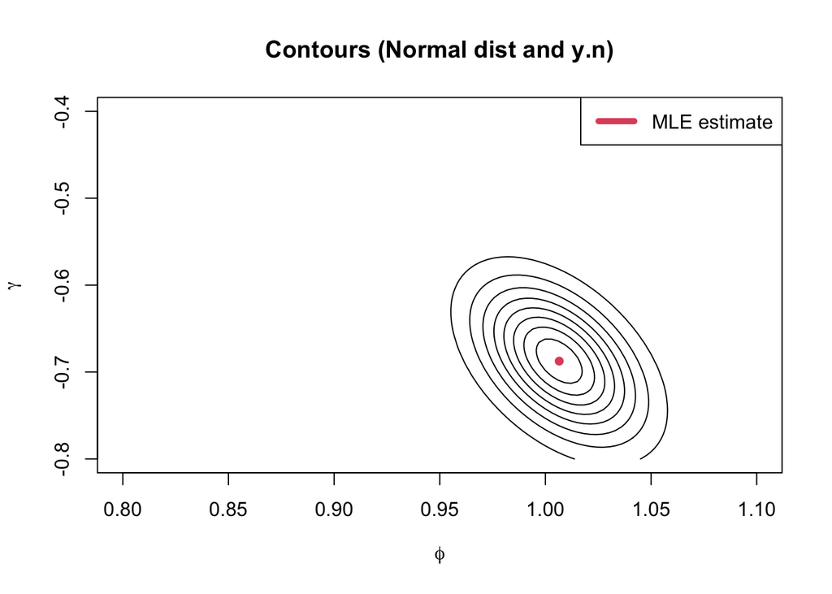

```r
N      = 100
phis = seq(0.8,1.1,length=N)
gammas = seq(-0.8,-0.4,length=N)

liken <- matrix(0,N,N)
liken.yt <- matrix(0,N,N)
liket <- matrix(0,N,N)
liket.yn <- matrix(0,N,N)


## Filling matrix for gaussian and student's t distribution
for (i in 1:N)
  for (j in 1:N){
    liken[i,j] = like.norm(phis[i],gammas[j],mean(sig1))
  }

for (i in 1:N)
  for (j in 1:N){
    liken.yt[i,j] = like.norm.yt(phis[i],gammas[j],mean(sig1))
  }

for (i in 1:N)
  for (j in 1:N){
    liket[i,j] = like.t(phis[i],gammas[j],mean(sig1t))
  }

for (i in 1:N)
  for (j in 1:N){
    liket.yn[i,j] = like.t.yn(phis[i],gammas[j],mean(sig1t))
  }

## Contours
contour(phis,gammas,liken,drawlabels=FALSE,
        xlab=expression(phi),ylab=expression(gamma),
        main="Contours (Normal dist and y.n)")
points(phi.mle.norm,gamma.mle.norm,col=2,pch=16)
legend("topright",legend=c("MLE estimate"),col=2,lty=1,lwd=5)
```

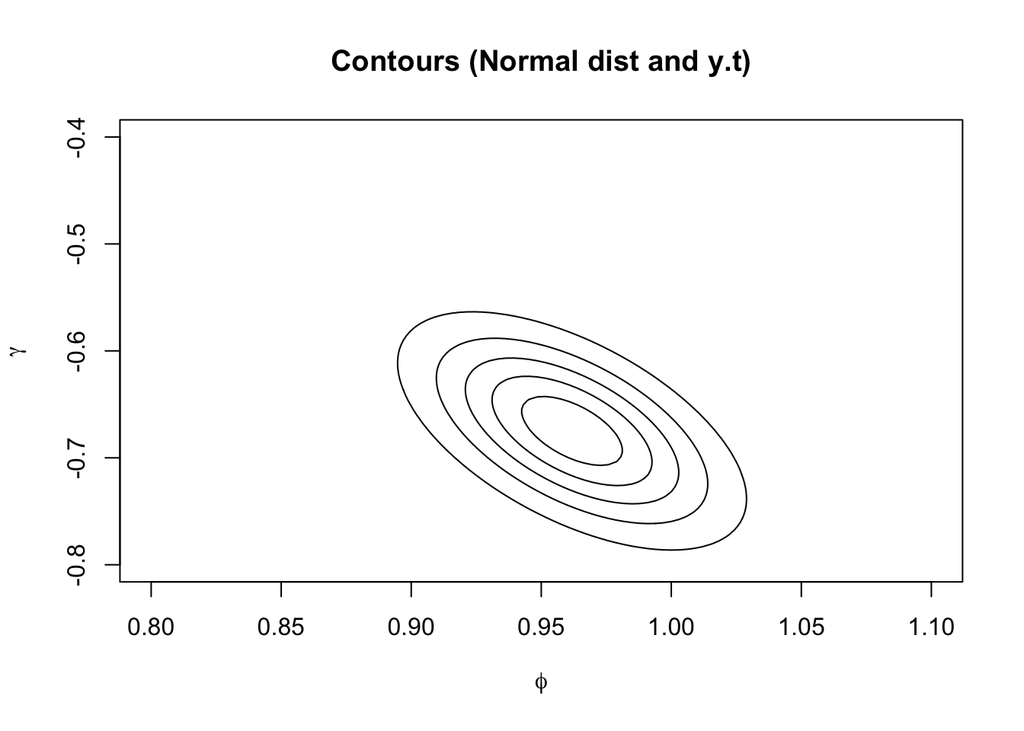

```r
contour(phis,gammas,liken.yt,drawlabels=FALSE,
        xlab=expression(phi),ylab=expression(gamma),
        main="Contours (Normal dist and y.t)")
```

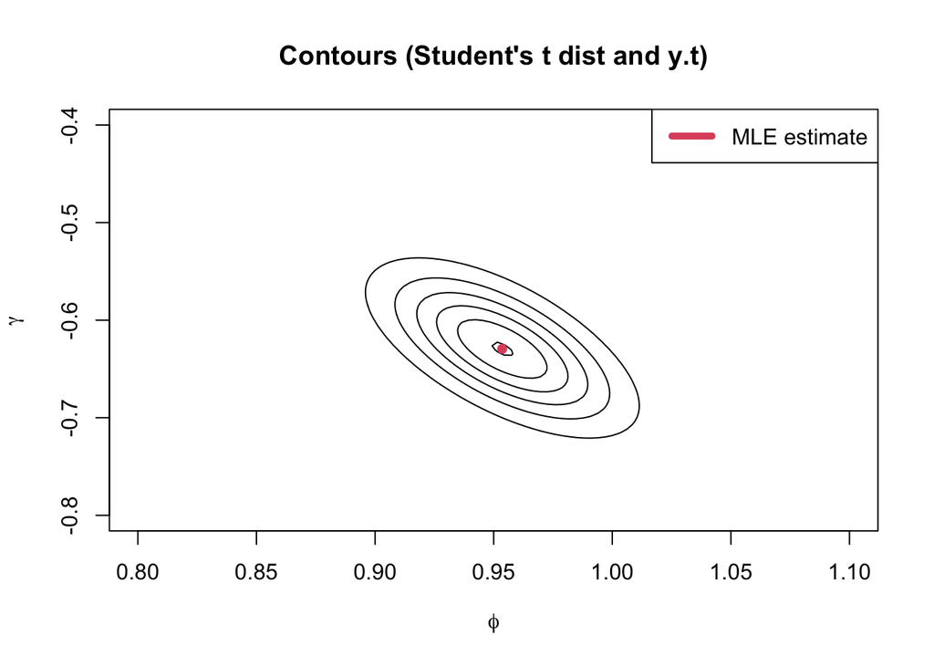

```r
contour(phis,gammas,liket,drawlabels=FALSE,
        xlab=expression(phi),ylab=expression(gamma),
        main="Contours (Student's t dist and y.t)")
points(phi.mle.t,gamma.mle.t,col=2,pch=16)
legend("topright",legend=c("MLE estimate"),col=2,lty=1,lwd=5)
```

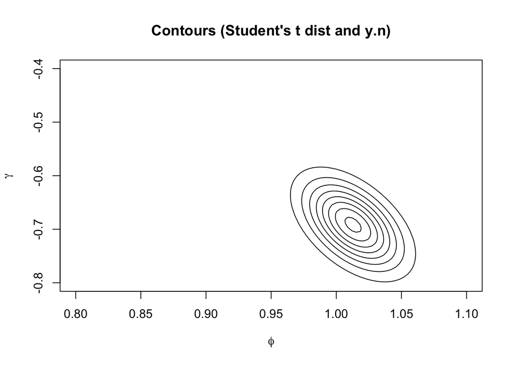

```r
contour(phis,gammas,liket.yn,drawlabels=FALSE,
        xlab=expression(phi),ylab=expression(gamma),
        main="Contours (Student's t dist and y.n)")
```

Computing the posterior probability that $\phi>0.9$ under both models.

```r
## Normal dist and y.n

#tail = round(100*(1-pnorm(0.9,mean.phi1n,sqrt(var(phi1)))),2)
tail = mean(phi1 > 0.9)
paste("Pr(phi_normal>0.9|data)=", tail, "%")
```

```
## [1] "Pr(phi_normal>0.9|data)= 0.9999 %"
```

```r
## Normal dist and y.t
tail = mean(phi1.yt > 0.9)
paste("Pr(phi_normal.yt>0.9|data)=", tail, "%")
```

```
## [1] "Pr(phi_normal.yt>0.9|data)= 0.85231 %"
```

```r
## Student's t dist and y.t
tail = mean(phi1t>0.9)
paste("Pr(phi_t>0.9|data)=", tail, "%")
```

```
## [1] "Pr(phi_t>0.9|data)= 0.98193 %"
```

```r
## Student's t dist and y.n
tail = mean(phi1t.yn>0.9)
paste("Pr(phi_t.yn>0.9|data)=", tail, "%")
```

```
## [1] "Pr(phi_t.yn>0.9|data)= 0.99999 %"
```

# 4 Prior predictive, Bayes factor and posterior model probability.

1. Computing both prior predictive densities
   $$p\left(y^{n} \mid \mathcal{M}_{j}\right)=\int_{0}^{\infty} \int_{-1}^{1} \int_{-1}^{1} \prod_{t=1}^{n} p\left(y_{t} \mid y_{t-1}, \theta, \mathcal{M}_{j}\right) d \phi d \gamma d \sigma^{2}$$
   via Monte Carlo by
   $$\widehat{p}\left(y^{n} \mid \mathcal{M}_{j}\right)=\frac{1}{M} \sum_{i=1}^{M} p\left(y_{t} \mid y_{t-1}, \phi^{(i)}, \gamma^{(i)}, \sigma^{2(i)} \mathcal{M}_{j}\right)$$
   where $\theta^{(1)},...,\theta^{(M)}$ are the draws from the prio $p(\theta)$.

```r
M <- 100000
phi = runif(M,-1,1)
gamma = runif(M,-1,1)
sig = runif(M,0.5,5)


## Functions used here are the ones calculated in item 2, considering the same especifications.
prob.n <- mean(likenn*prior.norm(phi,gamma,sig))
print(paste("Prior predictive normal dist and y.n= ",prob.n,sep=""))
```

```
## [1] "Prior predictive normal dist and y.n= 1.53636861842861e-224"
```

```r
prob.n.yt <- mean(likenn.yt*prior.norm(phi,gamma,sig))
print(paste("Prior predictive normal dist and y.t= ",prob.n.yt,sep=""))
```

```
## [1] "Prior predictive normal dist and y.t= 1.02887799405382e-228"
```

```r
prob.t <- mean(likent*prior.t(phi,gamma,sig))
print(paste("Prior predictive Student's t dist and y.t= ",prob.t,sep=""))
```

```
## [1] "Prior predictive Student's t dist and y.t= 4.17303703531737e-205"
```

```r
prob.t.yn <- mean(likent.yn*prior.t(phi,gamma,sig))
print(paste("Prior predictive Student's t dist and y.n = ",prob.t.yn,sep=""))
```

```
## [1] "Prior predictive Student's t dist and y.n = 6.1600561812838e-231"
```

2. Monte Carlo approximation to the Bayes factor for the gaussian model

```r
BF01   = prob.n/prob.t.yn
print(paste("Bayes factor normal vs student's t = ",round(BF01,3),sep=""))
```

```
## [1] "Bayes factor normal vs student's t = 2494082.153"
```

Monte Carlo approximation to the Bayes factor for the Student’s t model

```r
BF01.t   = prob.t/prob.n.yt
print(paste("Bayes factor normal vs student's t = ",round(BF01.t,3),sep=""))
```

```
## [1] "Bayes factor normal vs student's t = 4.05591047668872e+23"
```

3. Calculating the posterior model probability of the Gaussian model.

```r
PMP.n       = prob.n/(prob.n+prob.t.yn)
print(paste("Posterior model probability for Gaussian model = ",PMP.n,sep=""))
```

```
## [1] "Posterior model probability for Gaussian model = 0.999999599051059"
```